# Data-Driven Insights for Converting Casual Riders into Annual Members

Wouter Driessen

2023-03-17

## Business Task:

In this case-study the marketing analyst team at the fictional company Cyclistic wants to understand the differences in usage patterns between annual members and casual riders to design a new marketing strategy aimed at converting casual riders into annual members. The goal is to analyze historical bike trip data to identify patterns and insights that can be used to support data-driven recommendations.

### Research quenstion:

How do annual members and casual riders use Cyclistic bikes differently?

### Loading the data files

Loading the data files from April 2020 to march 2021 and combining into a data frame.

```r
df1 <- read.csv("202004-divvy-tripdata.csv")
df2 <- read.csv("202005-divvy-tripdata.csv")
df3 <- read.csv("202006-divvy-tripdata.csv")
df4 <- read.csv("202007-divvy-tripdata.csv")
df5 <- read.csv("202008-divvy-tripdata.csv")
df6 <- read.csv("202009-divvy-tripdata.csv")
df7 <- read.csv("202010-divvy-tripdata.csv")
df8 <- read.csv("202011-divvy-tripdata.csv")
df9 <- read.csv("202012-divvy-tripdata.csv")
df10 <- read.csv("202101-divvy-tripdata.csv")
df11 <- read.csv("202102-divvy-tripdata.csv")
df12 <- read.csv("202103-divvy-tripdata.csv")
bike_rides <- rbind(df1,df2,df3,df4,df5,df6,df7,df8,df9,df9,df10,df11,df12)
```

### Data Cleaning

The data was cleaned by setting appropriate data types and removing rows with negative duration times for bike rides.

```r
# Cleaning potential empty rows or colomns
bike_data <- remove_empty(bike_rides, which = c("rows","cols"))

#Converting character data to date format
bike_rides$started_at <- ymd_hms(bike_rides$started_at)
bike_rides$ended_at <- ymd_hms(bike_rides$ended_at)


# Omitting negative duration
bike_rides$started_at <- ymd_hms(bike_rides$started_at)
bike_rides$ended_at <- ymd_hms(bike_rides$ended_at)
bike_rides$duration <- difftime(bike_rides$ended_at, bike_rides$started_at, units = "min")
bike_rides <- bike_rides %>% filter(duration >0)
```

### Data Exploration

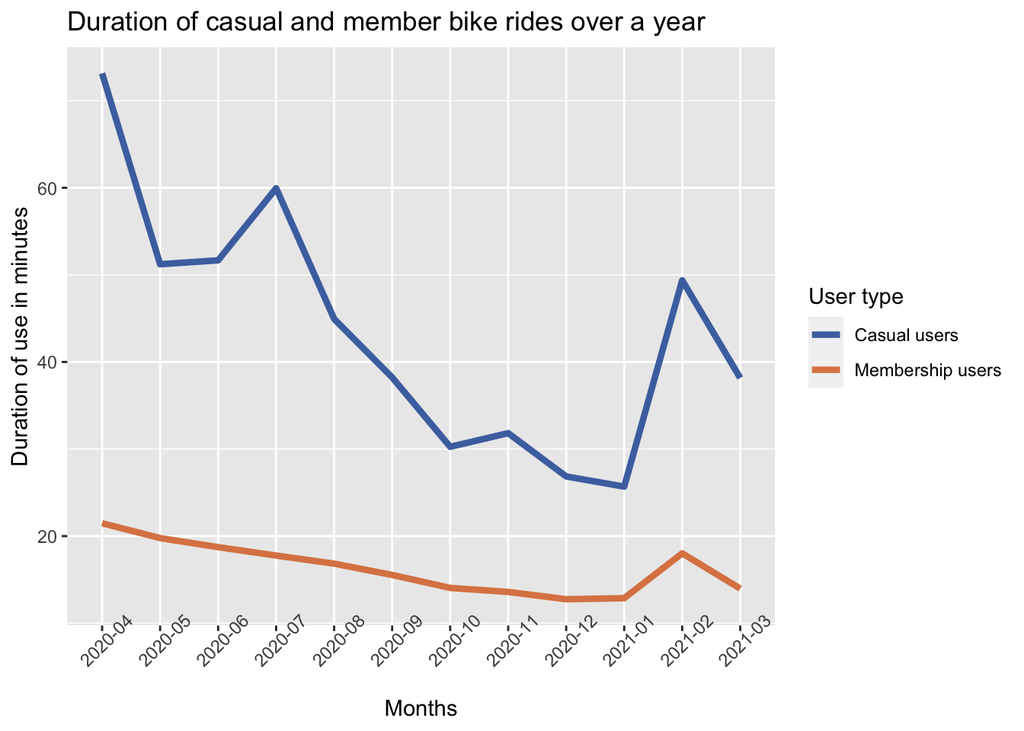

```r
# Define colors
c1 <- "#4C72B0" # dark blue
c2 <- "#DD8452" # orange
# Line graph showing average duration over 12 months.
bike_rides %>%
    group_by(month=format(started_at,"%Y-%m"), member_casual) %>%
    summarise(avgduration= mean(duration)) %>%
    ggplot(aes(x=month, y=avgduration, color=member_casual, group = member_casual)) +
    geom_line(aes(color = member_casual),size = 1.5)+
    theme(axis.text.x = element_text(angle = 45)) +
    scale_color_manual(values=c('casual'=c1, 'member'=c2),
                     labels=c('Casual users','Membership users')) +
   labs(title="Duration of casual and member bike rides over a year",
         x="Months",
         y="Duration of use in minutes",
         color="User type")
```